# Final project

```r
# save
#ggsave("figures/dbp_v_rna_expresion.pdf")
```

#results ## There is a positive trend when looking at number of transcripts and DBPs bound the a site for both lnc and mRNA, which is expected. Also as seen in previous results there is a sort of plateaue where the DBPs bound decreases and levelks out.

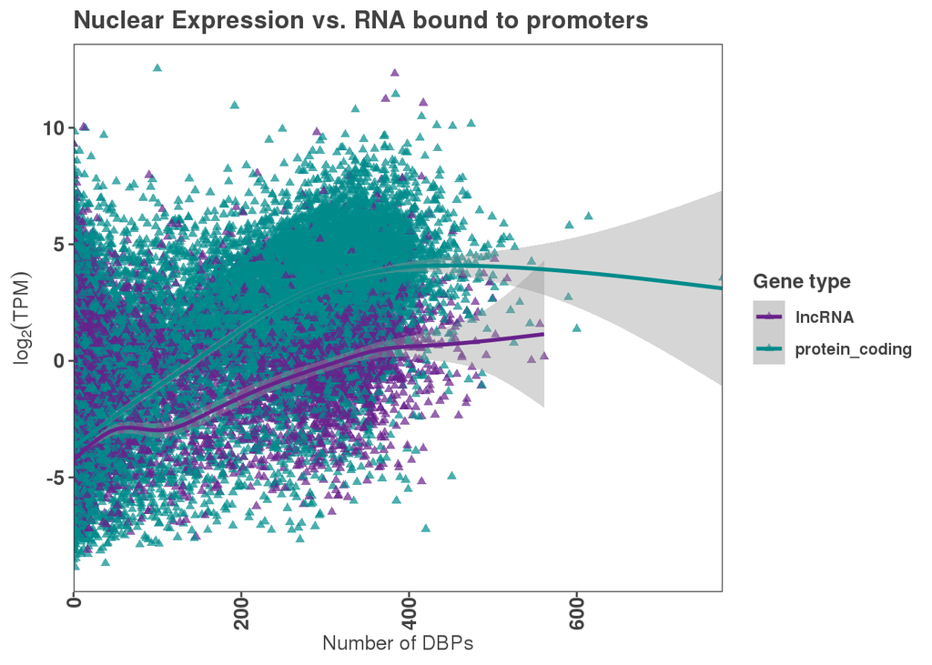

```r
#plot nuclear RNA abundance v number of DBPs bound to promoter
ggplot(promoter_features_df,
            aes(y = log2(tpm_homo_sapiens_nuclear_fraction + 0.001), x = number_of_dbp, color = gene_type)) +
  geom_point(data = promoter_features_df %>% filter(tpm_homo_sapiens_nuclear_fraction > 0.001),
             shape = 17, alpha = 0.7) +
  geom_smooth(method = 'gam', formula = y ~ s(x, bs = "cs")) +
  scale_x_continuous(expand = c(0,0)) +
  scale_color_manual(values = c("darkorchid4", "cyan4"), name = "Gene type") +
  ggtitle("Nuclear Expression vs. RNA bound to promoters") +
  xlab(expression('Number of DBPs')) +
  ylab(expression(log[2](TPM)))
```

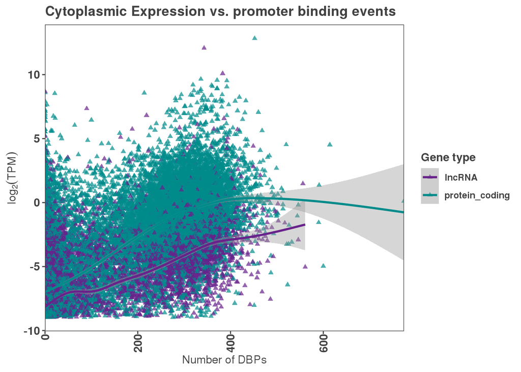

```r
# saving figure
#ggsave("figures/nuc_expression_v_promoter_bound.pdf")

# plot cyto RNA abundance v # DBP on promoters
ggplot(promoter_features_df,
            aes(y = log2(tpm_homo_sapiens_cytosolic_fraction + 0.001), x = number_of_dbp, color = gene_type)) +
  geom_point(data = promoter_features_df %>% filter(tpm_homo_sapiens_cytosolic_fraction > 0.001),
             shape = 17, alpha = 0.7) +
  geom_smooth(method = 'gam', formula = y ~ s(x, bs = "cs")) +
  scale_x_continuous(expand = c(0,0)) +
  scale_color_manual(values = c("darkorchid4", "cyan4"), name = "Gene type") +
  ggtitle("Cytoplasmic Expression vs. promoter binding events") +
  xlab(expression('Number of DBPs')) +
  ylab(expression(log[2](TPM)))
```

```r
# saving figure
#ggsave("figures/cyto_expression_v_promoter_bound.pdf")
```

#Results ##Cytoplasmic expression is in less abundance than nuclear expression, and the regression line has a slight drop that is seen on the nuclear expression. These results confirm previous results made about cytoplasmic and nuclear expression.

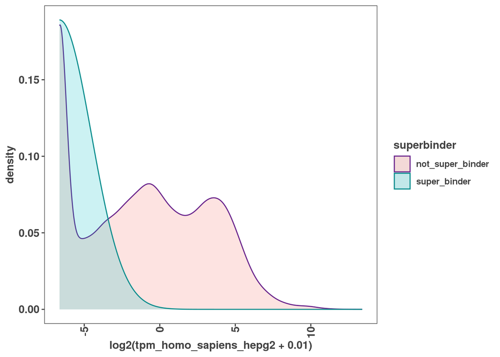

```r
# If we zoom in on high binding promoters (> 200 DBPs) are there any that don't have any expression?

promoter_features_df$hepg2_reservoir <-
  (promoter_features_df$number_of_dbp > 200 &
               promoter_features_df$tpm_homo_sapiens_hepg2 < 0.001)

# filtering super binders
promoter_features_df <- promoter_features_df %>%
  mutate(superbinder = promoter_features_df$number_of_dbp > 200)

# setting column of superbinders
promoter_features_df <- promoter_features_df %>%
  mutate(superbinder = ifelse(promoter_features_df$hepg2_reservoir ==T, "super_binder", "not_super_binder"))

# make density plot superbinder vs non superbinder expression in total RNA
ggplot(promoter_features_df, aes(x = log2(tpm_homo_sapiens_hepg2 + 0.01), color = superbinder, fill = superbinder))+
  geom_density(alpha = 0.2) +
  scale_color_manual(values = c("darkorchid4", "cyan4"))
```

```r
# saving figure
#ggsave("figures/reservoir_v_not_rna_density.pdf")

# if we zoom in on high binding promoters (> 200 DBPs) are there any that don't have any expression?
no_expression_tpm <- filter(promoter_features_df, tpm_homo_sapiens_hepg2 < 0.1)

no_exp_high_binder_tpm <- filter(no_expression_tpm, superbinder == TRUE)

# save df as
write.csv(no_exp_high_binder_tpm, "results/no_exp_high_binder_tpm.csv", row.names=TRUE)

lengthnoexp_highbinder <- nrow(no_exp_high_binder_tpm)

#print(paste0("There are ", lengthnoexp_highbinder, " super binders with no expression (TPM value of < 0.1)."))
```

[output not shown]